# Mammal data - Negev Highlands

Talia Gabay & Ron Chen

2025-11-11

```r
P <- P_byplot[grepl("Negev Highlands",Unit),][order(Cycle_number,Site)][,Site:=factor(Site)]
```

## Negev Highlands - Richness by camera

Monitoring started in 2014 (5 monitoring cycles), Each site as two types of plots - near or far from Settlements. There are 5 sites total - Bislach, Ezuz, Merhav Am, Sde Boker, Yeruham Each has 5 sampling points except for Sde Boker(near) which is missing samples from the first year (2014)

Let’s first validate the data:

```r
#include rare species in analysis
P.anal <- copy(P) # set a fixed variable name for analysis, if want to switch between data WITH rare #species and data WITHOUT rare species then only change once here
#Validate factors and levels
P.anal$Settlements <- as.factor(P.anal$Settlements)
print("Settlements has 2 levels")
```

```
## [1] "Settlements has 2 levels"
```

```r
print(levels(P.anal$Settlements))
```

```
## [1] "Far"  "Near"
```

```r
P.anal$Site <- as.factor(P.anal$Site)
print("Site has 5 levels")
```

```
## [1] "Site has 5 levels"
```

```r
print(levels(P.anal$Site))
```

```
## [1] "Bislach"   "Ezuz"      "Merhav Am" "Sde Boker" "Yeruham"
```

```r
P.anal$Transect <- as.factor(P.anal$Transect)
print("Transect has 10 levels")
```

```
## [1] "Transect has 10 levels"
```

```r
print(levels(P.anal$Transect))
```

```
##  [1] "Bislach Far"    "Bislach Near"   "Ezuz Far"       "Ezuz Near"
##  [5] "Merhav Am Far"  "Merhav Am Near" "Sde Boker Far"  "Sde Boker Near"
##  [9] "Yeruham Far"    "Yeruham Near"
```

```r
P.anal$Transect_with_date <- as.factor(P.anal$Transect_with_date)
print("Transect with date has 49 levels - Missing data for Sde Boker near in 2014")
```

```
## [1] "Transect with date has 49 levels - Missing data for Sde Boker near in 2014"
```

```r
print(levels(P.anal$Transect_with_date))
```

```
##  [1] "Bislach Far_02_07_2014"    "Bislach Far_04_01_2019"
##  [3] "Bislach Far_12_10_2022"    "Bislach Far_16_10_2020"
##  [5] "Bislach Far_19_10_2016"    "Bislach Near_02_07_2014"
##  [7] "Bislach Near_04_01_2019"   "Bislach Near_12_10_2022"
##  [9] "Bislach Near_16_10_2020"   "Bislach Near_19_10_2016"
## [11] "Ezuz Far_01_02_2019"       "Ezuz Far_06_11_2022"
## [13] "Ezuz Far_09_10_2020"       "Ezuz Far_20_09_2016"
## [15] "Ezuz Far_26_06_2014"       "Ezuz Near_01_02_2019"
## [17] "Ezuz Near_06_11_2022"      "Ezuz Near_09_10_2020"
## [19] "Ezuz Near_20_09_2016"      "Ezuz Near_26_06_2014"
## [21] "Merhav Am Far_05_10_2020"  "Merhav Am Far_19_06_2014"
## [23] "Merhav Am Far_20_01_2019"  "Merhav Am Far_23_06_2016"
## [25] "Merhav Am Far_29_09_2022"  "Merhav Am Near_05_10_2020"
## [27] "Merhav Am Near_19_06_2014" "Merhav Am Near_20_01_2019"
## [29] "Merhav Am Near_23_06_2016" "Merhav Am Near_29_09_2022"
## [31] "Sde Boker Far_11_08_2016"  "Sde Boker Far_18_09_2022"
## [33] "Sde Boker Far_20_10_2020"  "Sde Boker Far_29_06_2014"
## [35] "Sde Boker Far_30_12_2018"  "Sde Boker Near_11_08_2016"
## [37] "Sde Boker Near_18_09_2022" "Sde Boker Near_20_10_2020"
## [39] "Sde Boker Near_30_12_2018" "Yeruham Far_11_12_2018"
## [41] "Yeruham Far_14_07_2014"    "Yeruham Far_17_09_2020"
## [43] "Yeruham Far_24_08_2016"    "Yeruham Far_31_10_2022"
## [45] "Yeruham Near_11_12_2018"   "Yeruham Near_14_07_2014"
## [47] "Yeruham Near_17_09_2020"   "Yeruham Near_24_08_2016"
## [49] "Yeruham Near_31_10_2022"
```

```r
#distance.rescaled <- scale(all.mammal.abundances$Distance)
#write.csv(distance.rescaled, file = "Distance_rescaled.csv")
```

```r
print("RICHNESS WITH RARE SPECIES")
```

```
## [1] "RICHNESS WITH RARE SPECIES"
```

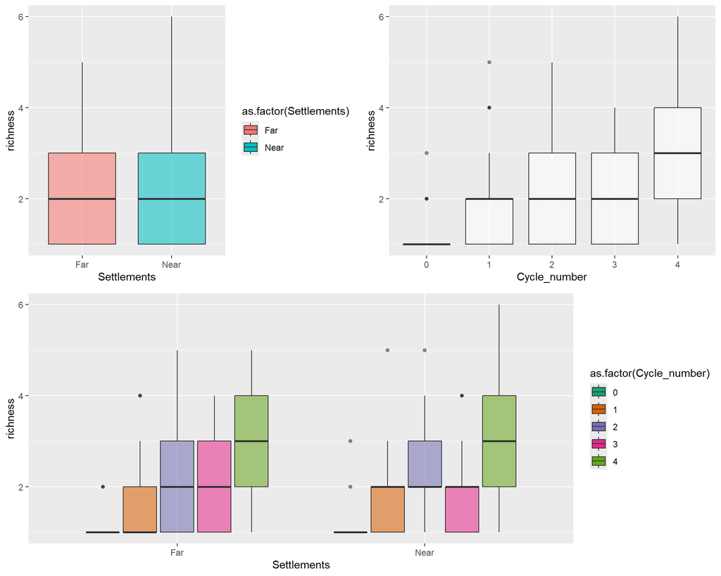

```r
plot_alpha_diversity(P, x_val = "Settlements", y_val = "richness", ylab_val = "richness", xlab_val = "Settlements", fill_val = "Settlements")
```

```r
col_names <- c("Cycle_number",  "Deployment.id_new",    "Unit", "Subunit",  "Site", "Settlements",  "Distance_rescaled","Lon",  "Lat", "year", "rescaled_Time.Diff", "sinus_Monitoring.Time.Diff", "cosinus_Monitoring.Time.Diff", "Transect", "Transect_with_date")

abu_by_spp.NegevHighlands <- all.mammal.abundances[grepl("Negev Highlands",Unit),]
spp <- abu_by_spp.NegevHighlands[,27:40]
#spp <- abu_by_spp.NegevHighlands[,25:38]
# filter out species with zero counts
print(colSums(spp))
```

```
##      Canis aureus       Canis lupus     Capra nubiana Dama mesopotamica
##               973                 4                11                 0
##    Equus hemionus    Gazella dorcas   Gazella gazella     Hyaena hyaena
##                16               190                 0               128
##    Hystrix indica    Lepus capensis       Meles meles     Oryx leucoryx
##               607               177                 0                 0
##        Sus scrofa     Vulpes vulpes
##                 0               465
```

```
## Overlapping points were shifted along the y-axis to make them visible.
```

```
##
##  PIPING TO 2nd MVFACTOR
```

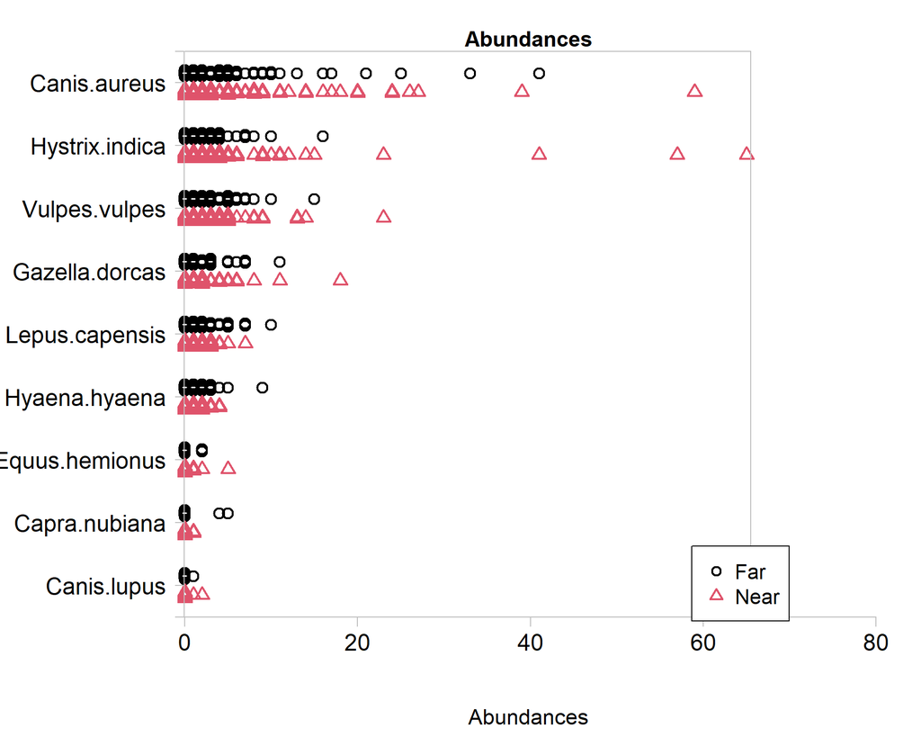

```r
spp <- spp[,.SD,.SDcols = colSums(spp)>0]
spp <- mvabund(spp)

plot(spp ~ P.anal$Settlements, overall.main="raw abundances", transformation = "no")
```

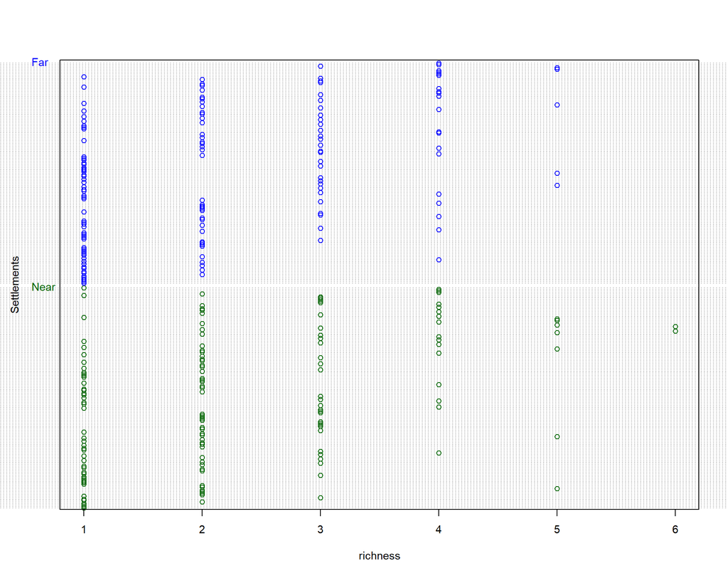

```r
my_cols <- c("blue", "darkgreen")
dotchart(P.anal$richness, ylab = "Settlements",
         groups = P.anal$Settlements, gcolor = my_cols,
         color = my_cols[P.anal$Settlements],
         cex = 0.9,  pch = 1, xlab = "richness")
```

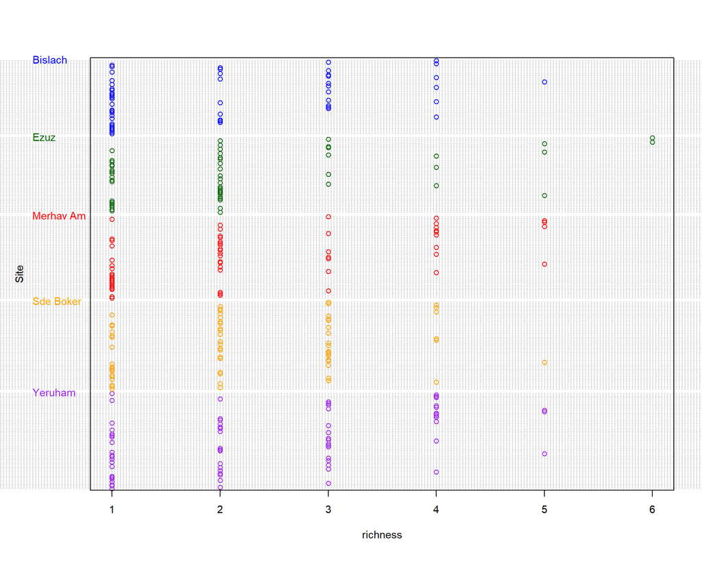

```r
my_cols <- c("blue", "darkgreen", "red", "orange", "purple")
dotchart(P.anal$richness, ylab = "Site",
         groups = P.anal$Site, gcolor = my_cols,
         color = my_cols[P.anal$Site],
         cex = 0.9,  pch = 1, xlab = "richness")
```

```r
kable(summary(P.anal[,.(richness, abundance, Distance_rescaled, rescaled_Time.Diff, cosinus_Monitoring.Time.Diff, sinus_Monitoring.Time.Diff, Site, Transect, Transect_with_date)]))
```

|  | richness | abundance | Distance_rescaled | rescaled_Time.Diff | cosinus_Monitoring.Time.Diff | sinus_Monitoring.Time.Diff | Site | Transect | Transect_with_date |
| --- | --- | --- | --- | --- | --- | --- | --- | --- | --- |
|  | Min. :1.000 | Min. : 1.000 | Min. :-0.91363 | Min. :-1.2179 | Min. :-0.9990 | Min. :-0.99999 | Bislach :53 | Yeruham Near : 37 | Bislach Near_12_10_2022 : 9 |
|  | 1st Qu.:1.000 | 1st Qu.: 2.000 | 1st Qu.:-0.63636 | 1st Qu.:-0.4809 | 1st Qu.:-0.4161 | 1st Qu.:-0.50637 | Ezuz :54 | Sde Boker Near: 34 | Sde Boker Near_18_09_2022: 9 |
|  | Median :2.000 | Median : 5.000 | Median : 0.06859 | Median : 0.7539 | Median : 0.3590 | Median :-0.09718 | Merhav Am:59 | Yeruham Far : 32 | Sde Boker Near_20_10_2020: 9 |
|  | Mean :2.235 | Mean : 8.628 | Mean :-0.01456 | Mean : 0.4169 | Mean : 0.1602 | Mean :-0.01436 | Sde Boker:63 | Bislach Far : 30 | Sde Boker Near_30_12_2018: 9 |
|  | 3rd Qu.:3.000 | 3rd Qu.:11.000 | 3rd Qu.: 0.49839 | 3rd Qu.: 1.3855 | 3rd Qu.: 0.8623 | 3rd Qu.: 0.67023 | Yeruham :69 | Merhav Am Near: 30 | Yeruham Far_31_10_2022 : 9 |
|  | Max. :6.000 | Max. :70.000 | Max. : 1.12569 | Max. : 1.4278 | Max. : 0.9994 | Max. : 0.99882 | NA | Ezuz Far : 29 | Yeruham Near_11_12_2018 : 9 |
|  | NA | NA | NA | NA | NA | NA | NA | (Other) :106 | (Other) :244 |

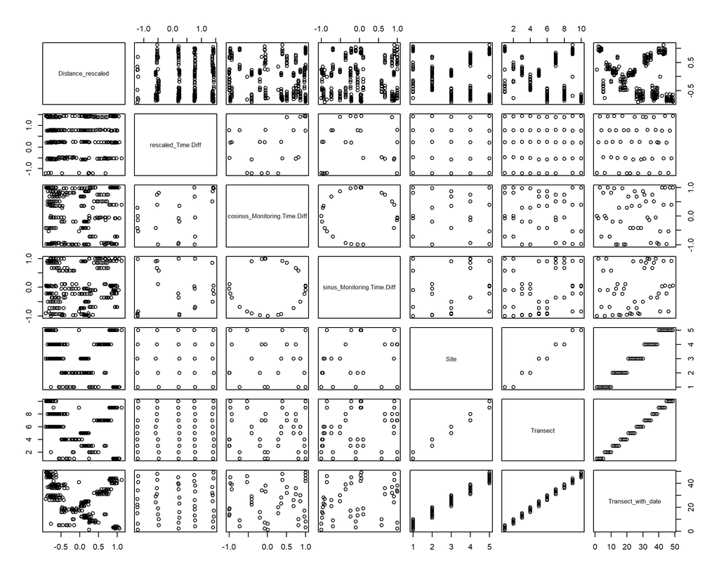

```r
pairs(P.anal[,lapply(X = .SD,FUN = as.numeric),.SDcols=c("Distance_rescaled","rescaled_Time.Diff","cosinus_Monitoring.Time.Diff","sinus_Monitoring.Time.Diff","Site","Transect","Transect_with_date")])
```

```r
kable(cor(P.anal[,lapply(X = .SD,FUN = as.numeric),.SDcols=c("Distance_rescaled","rescaled_Time.Diff","cosinus_Monitoring.Time.Diff","sinus_Monitoring.Time.Diff","Site","Transect","Transect_with_date")]))
```

|  | Distance_rescaled | rescaled_Time.Diff | cosinus_Monitoring.Time.Diff | sinus_Monitoring.Time.Diff | Site | Transect | Transect_with_date |
| --- | --- | --- | --- | --- | --- | --- | --- |
| Distance_rescaled | 1.0000000 | 0.0760419 | -0.0276814 | 0.0574501 | -0.1913315 | -0.3192192 | -0.3191631 |
| rescaled_Time.Diff | 0.0760419 | 1.0000000 | 0.4169221 | -0.0144697 | 0.0116821 | 0.0229156 | 0.0334149 |
| cosinus_Monitoring.Time.Diff | -0.0276814 | 0.4169221 | 1.0000000 | 0.0923914 | 0.0500147 | 0.0434014 | 0.0495119 |
| sinus_Monitoring.Time.Diff | 0.0574501 | -0.0144697 | 0.0923914 | 1.0000000 | 0.2655165 | 0.2569541 | 0.2716732 |
| Site | -0.1913315 | 0.0116821 | 0.0500147 | 0.2655165 | 1.0000000 | 0.9853042 | 0.9806464 |
| Transect | -0.3192192 | 0.0229156 | 0.0434014 | 0.2569541 | 0.9853042 | 1.0000000 | 0.9952240 |
| Transect_with_date | -0.3191631 | 0.0334149 | 0.0495119 | 0.2716732 | 0.9806464 | 0.9952240 | 1.0000000 |

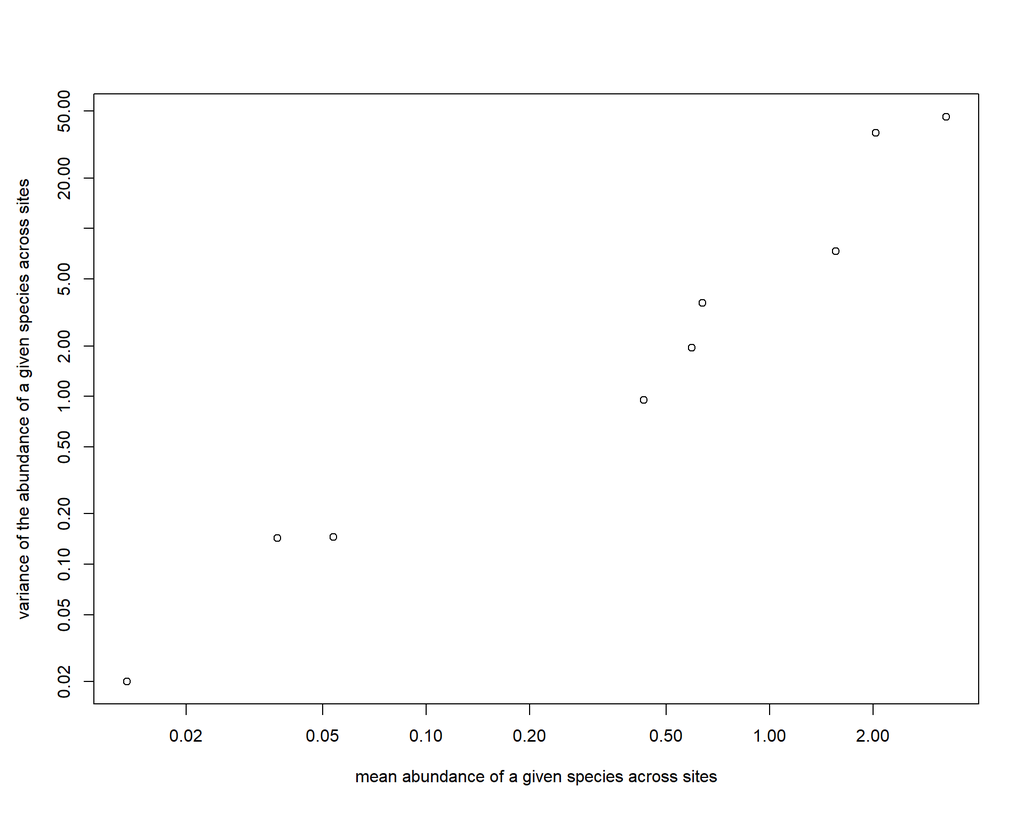

```r
meanvar.plot(spp, xlab = "mean abundance of a given species across sites", ylab = "variance of the abundance of a given species across sites")
```

```r
mdl_r.poiss.int <- glm(data = P.anal, formula = richness ~ Distance_rescaled * rescaled_Time.Diff + cosinus_Monitoring.Time.Diff + sinus_Monitoring.Time.Diff + Site + Transect_with_date, family = poisson)
od <- mdl_r.poiss.int$deviance/mdl_r.poiss.int$df.residual
print("Estimating overdispersion parameter phi: (Res. Dev.)/(n-p) where n=number of observations; p=number of parameters in the model.")
```

```
## [1] "Estimating overdispersion parameter phi: (Res. Dev.)/(n-p) where n=number of observations; p=number of parameters in the model."
```

```r
print(paste0('od = ',od))
```

```
## [1] "od = 0.451806633794825"
```

Overdispersion parameter is <1 (underdispersion) and therefore will use Poisson

```r
m0 <- glm(data = P.anal, formula =  richness ~ Distance_rescaled * rescaled_Time.Diff + cosinus_Monitoring.Time.Diff + sinus_Monitoring.Time.Diff, family = poisson)

me0transectwithdate <- glmer(data = P.anal, formula =   richness ~ Distance_rescaled * rescaled_Time.Diff + cosinus_Monitoring.Time.Diff + sinus_Monitoring.Time.Diff +  (1|Transect_with_date), family = poisson, verbose = 1)
```

[output not shown]

```
## boundary (singular) fit: see help('isSingular')
```

```r
me0transect <- glmer(data = P.anal, formula =   richness ~ Distance_rescaled * rescaled_Time.Diff + cosinus_Monitoring.Time.Diff + sinus_Monitoring.Time.Diff +  (1|Transect), family = poisson, verbose = 1)
```

[output not shown]

```
## boundary (singular) fit: see help('isSingular')
```

```r
me0site <- glmer(data = P.anal, formula =   richness ~ Distance_rescaled * rescaled_Time.Diff + cosinus_Monitoring.Time.Diff + sinus_Monitoring.Time.Diff +  (1|Site), family = poisson, verbose = 1)
```

[output not shown]

```
## boundary (singular) fit: see help('isSingular')
```

All GLMERs result in singular fit, will use regular GLM:

```r
m1 <- step(m0)
```

```
## Start:  AIC=934.63
## richness ~ Distance_rescaled * rescaled_Time.Diff + cosinus_Monitoring.Time.Diff +
##     sinus_Monitoring.Time.Diff
##
##                                        Df Deviance    AIC
## - sinus_Monitoring.Time.Diff            1   149.68 932.63
## - Distance_rescaled:rescaled_Time.Diff  1   149.71 932.66
## - cosinus_Monitoring.Time.Diff          1   150.41 933.36
## <none>                                      149.67 934.63
##
## Step:  AIC=932.63
## richness ~ Distance_rescaled + rescaled_Time.Diff + cosinus_Monitoring.Time.Diff +
##     Distance_rescaled:rescaled_Time.Diff
##
##                                        Df Deviance    AIC
## - Distance_rescaled:rescaled_Time.Diff  1   149.71 930.67
## - cosinus_Monitoring.Time.Diff          1   150.43 931.38
## <none>                                      149.68 932.63
##
## Step:  AIC=930.67
## richness ~ Distance_rescaled + rescaled_Time.Diff + cosinus_Monitoring.Time.Diff
##
##                                Df Deviance    AIC
## - Distance_rescaled             1   150.11 929.06
## - cosinus_Monitoring.Time.Diff  1   150.45 929.41
## <none>                              149.71 930.67
## - rescaled_Time.Diff            1   172.77 951.72
##
## Step:  AIC=929.06
## richness ~ rescaled_Time.Diff + cosinus_Monitoring.Time.Diff
##
##                                Df Deviance    AIC
## - cosinus_Monitoring.Time.Diff  1   150.93 927.89
## <none>                              150.11 929.06
## - rescaled_Time.Diff            1   172.80 949.75
##
## Step:  AIC=927.89
## richness ~ rescaled_Time.Diff
##
##                      Df Deviance    AIC
## <none>                    150.93 927.89
## - rescaled_Time.Diff  1   184.96 959.91
```

```r
# m1 <- glmer(data = P.anal, formula = richness ~ Distance_rescaled * rescaled_Time.Diff + cosinus_Monitoring.Time.Diff + (1|Transect_with_date), family = poisson)
# drop1(m1)
```

Final model includes time difference

```r
summ(m1, exp = TRUE, digits=3)
```

| Observations | 298 |
| --- | --- |
| Dependent variable | richness |
| Type | Generalized linear model |
| Family | poisson |
| Link | log |

| χ²(1) | 34.027 |
| --- | --- |
| Pseudo-R² (Cragg-Uhler) | 0.112 |
| Pseudo-R² (McFadden) | 0.036 |
| AIC | 927.886 |
| BIC | 935.280 |

|  | exp(Est.) | 2.5% | 97.5% | z val. | p |
| --- | --- | --- | --- | --- | --- |
| (Intercept) | 1.933 | 1.756 | 2.128 | 13.469 | 0.000 |
| rescaled_Time.Diff | 1.328 | 1.205 | 1.464 | 5.702 | 0.000 |

Standard errors: MLE

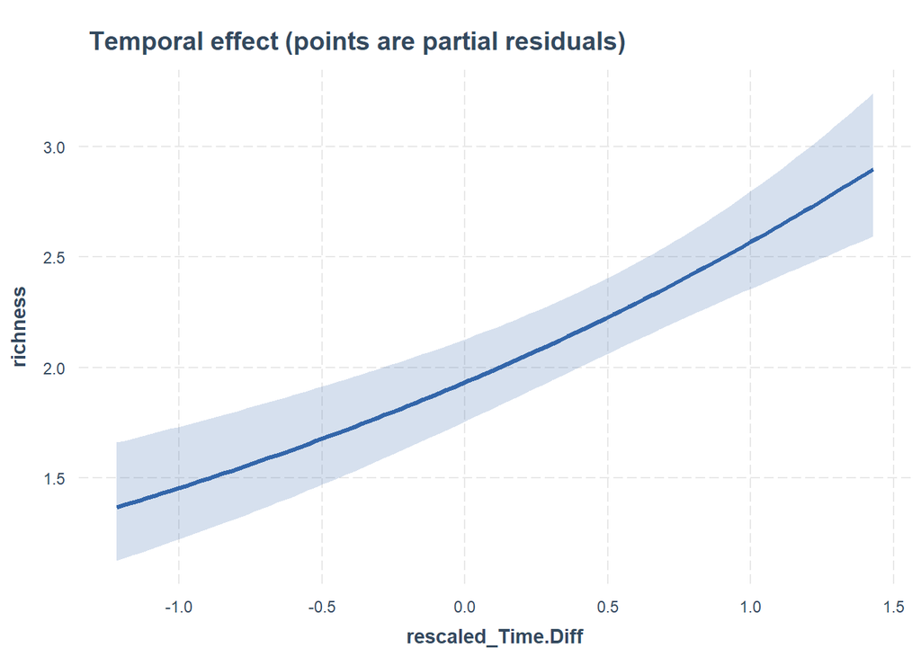

```r
effect_plot(model = m1, data=P.anal, pred = rescaled_Time.Diff, interval = T, plot.points = F, jitter = c(0.1,0), point.size = 3, cat.pred.point.size = 4, partial.residuals = F, colors = "Qual1", main.title = "Temporal effect (points are partial residuals)")
```

```r
#m_coef <- coef(m2)
#P.anal$Cycle_number <- as.numeric(P.anal$Cycle_number)
#plot(P.anal$Cycle_number,
 #    exp(m_coef["rescaled_Time.Diff"]*P.anal$rescaled_Time.Diff),
 #xlab = "Cycle number", ylab = "contribution to richness")
```

Time difference significantly affects species richness

#### community analysis using package MVabund

Table of abundances per species by camera ID

```r
abundance_and_cameras <- as.data.table(abu_by_spp.NegevHighlands[,c(5,27:40)])
dim(abundance_and_cameras)
```

```
## [1] 298  15
```

```r
canisau <- abundance_and_cameras[,2] > 0
sum(canisau)
```

```
## [1] 163
```

```r
canislup <- abundance_and_cameras[,3] > 0
sum(canislup)
```

```
## [1] 3
```

```r
capra <- abundance_and_cameras[,4] > 0
sum(capra)
```

```
## [1] 4
```

```r
Doma <- abundance_and_cameras[,5] > 0
sum(Doma)
```

```
## [1] 0
```

```r
Equus <- abundance_and_cameras[,6] > 0
sum(Equus)
```

```
## [1] 8
```

```r
Gazellador <- abundance_and_cameras[,7] > 0
sum(Gazellador)
```

```
## [1] 56
```

```r
Gazellagaz <- abundance_and_cameras[,8] > 0
sum(Gazellagaz)
```

```
## [1] 0
```

```r
Hyaena <- abundance_and_cameras[,9] > 0
sum(Hyaena)
```

```
## [1] 74
```

```r
Hystrix <- abundance_and_cameras[,10] > 0
sum(Hystrix)
```

```
## [1] 138
```

```r
Lepus <- abundance_and_cameras[,11] > 0
sum(Lepus)
```

```
## [1] 72
```

```r
Meles <- abundance_and_cameras[,12] > 0
sum(Meles)
```

```
## [1] 0
```

```r
Oryx <- abundance_and_cameras[,13] > 0
sum(Oryx)
```

```
## [1] 0
```

```r
Sus <- abundance_and_cameras[,14] > 0
sum(Sus)
```

```
## [1] 0
```

```r
Vulpus <- abundance_and_cameras[,15] > 0
sum(Vulpus)
```

```
## [1] 148
```

298 cameras

Species with a minimum of 20 cameras - Canis aureus, Gazella Dorcas, Hyaena hyaena, Hystrix indica, Lepus capensis, Vulpus vulpus

```r
spp_no_rare <- abu_by_spp.NegevHighlands[,27:40]
print(colSums(spp_no_rare))
```

```
##      Canis aureus       Canis lupus     Capra nubiana Dama mesopotamica
##               973                 4                11                 0
##    Equus hemionus    Gazella dorcas   Gazella gazella     Hyaena hyaena
##                16               190                 0               128
##    Hystrix indica    Lepus capensis       Meles meles     Oryx leucoryx
##               607               177                 0                 0
##        Sus scrofa     Vulpes vulpes
##                 0               465
```

```r
# filter out species with less than 20 individuals (rare species)
spp_no_rare <- spp_no_rare[,.SD,.SDcols = colSums(spp_no_rare)>=20]
spp_no_rare <- mvabund(spp_no_rare)
print(colSums(spp_no_rare))
```

```
##   Canis.aureus Gazella.dorcas  Hyaena.hyaena Hystrix.indica Lepus.capensis
##            973            190            128            607            177
##  Vulpes.vulpes
##            465
```

Left with 6 species after filtering

```r
env_data <- abu_by_spp.NegevHighlands[,..col_names]

mva_m0.po <- manyglm(formula = spp_no_rare ~ Distance_rescaled * rescaled_Time.Diff + cosinus_Monitoring.Time.Diff + sinus_Monitoring.Time.Diff, family = "poisson", data = env_data)

mva_m0.nb <- manyglm(formula = spp_no_rare ~ Distance_rescaled * rescaled_Time.Diff + cosinus_Monitoring.Time.Diff + sinus_Monitoring.Time.Diff, family = "negative.binomial", data = env_data)

aic_dt <- data.table(nb = mva_m0.nb$aic, po=mva_m0.po$aic)
colMeans(aic_dt)
```

```
##        nb        po
##  791.4671 1237.0394
```

```r
print("POISSON")
```

```
## [1] "POISSON"
```

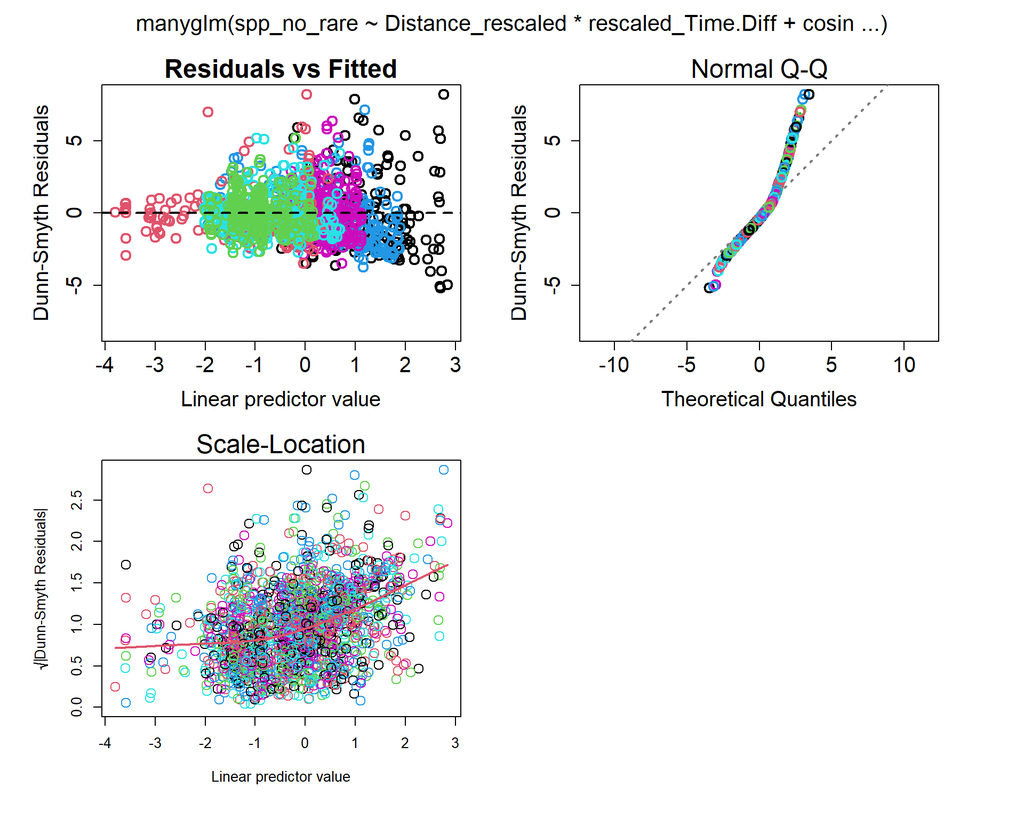

```r
plot(mva_m0.po, which=1:3)
```

```r
print("NEGATIVE BINOMIAL")
```

```
## [1] "NEGATIVE BINOMIAL"
```

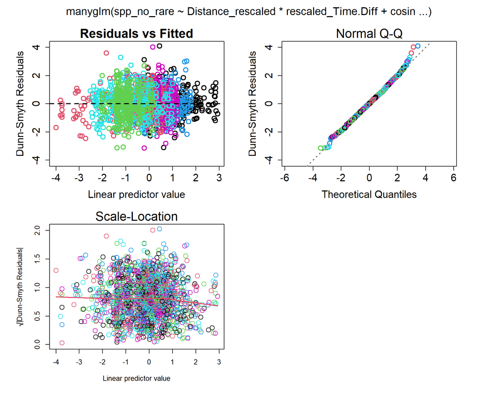

```r
plot(mva_m0.nb, which=1:3)
```

prefer negative binomial because standardized residuals are smaller.

```r
# mva_m0 <- mva_m0.po
# mva_m1 <- manyglm(formula = spp_no_rare ~ Distance_rescaled * rescaled_Time.Diff + dunes*rescaled_Time.Diff + Distance_rescaled:dunes + cos_td_rad + sin_td_rad + site, family = "poisson", data = env_data)
# aic_dt$po1 <- mva_m1$aic
mva_m0 <- mva_m0.nb
mva_m1 <- manyglm(formula = spp_no_rare ~ Distance_rescaled * rescaled_Time.Diff + cosinus_Monitoring.Time.Diff + sinus_Monitoring.Time.Diff + Transect_with_date, data = env_data)
aic_dt$nb1 <- mva_m1$aic
colMeans(aic_dt)
```

```
##        nb        po       nb1
##  791.4671 1237.0394  761.0316
```

```r
mva_m2 <- manyglm(formula = spp_no_rare ~ Distance_rescaled * rescaled_Time.Diff + cosinus_Monitoring.Time.Diff + sinus_Monitoring.Time.Diff + Transect, data = env_data)

aic_dt$nb2 <- mva_m2$aic
colMeans(aic_dt)
```

```
##        nb        po       nb1       nb2
##  791.4671 1237.0394  761.0316  765.2318
```

```r
mva_m3 <- manyglm(formula = spp_no_rare ~ Distance_rescaled * rescaled_Time.Diff + cosinus_Monitoring.Time.Diff + sinus_Monitoring.Time.Diff + Site, data = env_data)
aic_dt$nb3 <- mva_m2$aic
colMeans(aic_dt)
```

```
##        nb        po       nb1       nb2       nb3
##  791.4671 1237.0394  761.0316  765.2318  765.2318
```

Transect + date, Transect and Site improve the model.

## Many GLM with Site:

```r
mva_m0.nb <- manyglm(formula = spp_no_rare ~ Distance_rescaled * rescaled_Time.Diff + cosinus_Monitoring.Time.Diff + sinus_Monitoring.Time.Diff + Site, family = "negative.binomial", data = env_data)
drop1(mva_m0.nb)
```

```
## Single term deletions
##
## Model:
## spp_no_rare ~ Distance_rescaled * rescaled_Time.Diff + cosinus_Monitoring.Time.Diff +
##     sinus_Monitoring.Time.Diff + Site
##                                      Df    AIC
## <none>                                  4627.8
## cosinus_Monitoring.Time.Diff          6 4625.3
## sinus_Monitoring.Time.Diff            6 4622.1
## Site                                 24 4748.8
## Distance_rescaled:rescaled_Time.Diff  6 4637.2
```

Dropped sin time

```r
# mva_m2 <- manyglm(formula = spp_no_rare ~ Distance_rescaled + dunes*rescaled_Time.Diff + Distance_rescaled:dunes + cos_td_rad + sin_td_rad, family = "poisson", data = env_data)
mva_m2 <- manyglm(formula = spp_no_rare ~ Distance_rescaled * rescaled_Time.Diff + cosinus_Monitoring.Time.Diff + Site, family = "negative.binomial", data = env_data)
drop1(mva_m2)
```

```
## Single term deletions
##
## Model:
## spp_no_rare ~ Distance_rescaled * rescaled_Time.Diff + cosinus_Monitoring.Time.Diff +
##     Site
##                                      Df    AIC
## <none>                                  4622.1
## cosinus_Monitoring.Time.Diff          6 4619.1
## Site                                 24 4754.1
## Distance_rescaled:rescaled_Time.Diff  6 4630.4
```

Dropped cosin monitoring time

```r
# mva_m2 <- manyglm(formula = spp_no_rare ~ Distance_rescaled + dunes + rescaled_Time.Diff + Distance_rescaled:dunes + cos_td_rad + sin_td_rad, family = "poisson", data = env_data)
mva_m2 <- manyglm(formula = spp_no_rare ~ Distance_rescaled * rescaled_Time.Diff + Site, family = "negative.binomial", data = env_data)
drop1(mva_m2)
```

```
## Single term deletions
##
## Model:
## spp_no_rare ~ Distance_rescaled * rescaled_Time.Diff + Site
##                                      Df    AIC
## <none>                                  4619.1
## Site                                 24 4758.6
## Distance_rescaled:rescaled_Time.Diff  6 4627.3
```

Final model includes Site and the interaction between distance from settlement and time difference

```r
# mva_m2 <- manyglm(formula = spp_no_rare ~ Distance_rescaled + dunes + rescaled_Time.Diff + Distance_rescaled:dunes + cos_td_rad + sin_td_rad, family = "poisson", data = env_data)
# mva_m2 <- manyglm(formula = spp_no_rare ~ Distance_rescaled * rescaled_Time.Diff + Site, family = "negative.binomial", data = env_data)
# drop1(mva_m2)
```

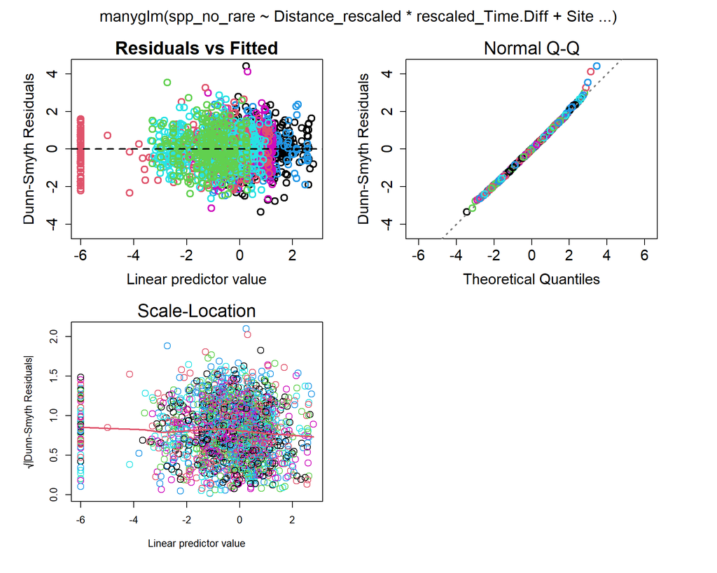

```r
plot(mva_m2, which=1:3)
```

```r
# summ_m2 <- summary(mva_m2)
# saveRDS(summ_m2, file = "../output/summ_negev_highlands_999iter.rds")
summ_m2 <- readRDS(file = "../output/summ_negev_highlands_999iter.rds")
print(summ_m2)
```

```
##
## Test statistics:
##                                      wald value Pr(>wald)
## (Intercept)                               5.829     0.001 ***
## Distance_rescaled                         6.848     0.001 ***
## rescaled_Time.Diff                        8.470     0.001 ***
## SiteEzuz                                  5.615     0.001 ***
## SiteMerhav Am                             5.633     0.002 **
## SiteSde Boker                             5.499     0.001 ***
## SiteYeruham                               5.695     0.001 ***
## Distance_rescaled:rescaled_Time.Diff      4.522     0.010 **
## ---
## Signif. codes:  0 '***' 0.001 '**' 0.01 '*' 0.05 '.' 0.1 ' ' 1
##
## Test statistic:  18.35, p-value: 0.001
## Arguments:
##  Test statistics calculated assuming response assumed to be uncorrelated
##  P-value calculated using 999 resampling iterations via pit.trap resampling (to account for correlation in testing).
```

```r
# anov_m2.uni <- anova(mva_m2, p.uni = "adjusted")
# saveRDS(anov_m2.uni, file = "../output/anova_negev_highlands_999iter.rds")
anov_m2.uni <- readRDS(file = "../output/anova_negev_highlands_999iter.rds")
print(anov_m2.uni)
```

```
## Analysis of Deviance Table
##
## Model: spp_no_rare ~ Distance_rescaled * rescaled_Time.Diff + Site
##
## Multivariate test:
##                                      Res.Df Df.diff    Dev Pr(>Dev)
## (Intercept)                             297
## Distance_rescaled                       296       1  97.14    0.001 ***
## rescaled_Time.Diff                      295       1  56.62    0.001 ***
## Site                                    291       4 187.52    0.001 ***
## Distance_rescaled:rescaled_Time.Diff    290       1  20.29    0.009 **
## ---
## Signif. codes:  0 '***' 0.001 '**' 0.01 '*' 0.05 '.' 0.1 ' ' 1
##
## Univariate Tests:
##                                      Canis.aureus          Gazella.dorcas
##                                               Dev Pr(>Dev)            Dev
## (Intercept)
## Distance_rescaled                          21.032    0.001          5.396
## rescaled_Time.Diff                         28.206    0.001          9.241
## Site                                       13.747    0.087         41.683
## Distance_rescaled:rescaled_Time.Diff        8.429    0.038           4.08
##                                               Hyaena.hyaena
##                                      Pr(>Dev)           Dev Pr(>Dev)
## (Intercept)
## Distance_rescaled                       0.040          2.31    0.150
## rescaled_Time.Diff                      0.011         7.259    0.030
## Site                                    0.001        22.716    0.015
## Distance_rescaled:rescaled_Time.Diff    0.220         1.285    0.619
##                                      Hystrix.indica          Lepus.capensis
##                                                 Dev Pr(>Dev)            Dev
## (Intercept)
## Distance_rescaled                             40.08    0.001         19.714
## rescaled_Time.Diff                            6.751    0.030          0.978
## Site                                         30.577    0.003         25.846
## Distance_rescaled:rescaled_Time.Diff          0.384    0.661          5.381
##                                               Vulpes.vulpes
##                                      Pr(>Dev)           Dev Pr(>Dev)
## (Intercept)
## Distance_rescaled                       0.001          8.61    0.010
## rescaled_Time.Diff                      0.323         4.185    0.090
## Site                                    0.007        52.954    0.001
## Distance_rescaled:rescaled_Time.Diff    0.137         0.733    0.661
## Arguments:
##  Test statistics calculated assuming uncorrelated response (for faster computation)
## P-value calculated using 999 iterations via PIT-trap resampling.
```

**Multivariate test shows that site, distance from settlements, time difference and the interaction between distance from settlement and time difference statistically affect species composition**

```r
coefp <- merge(data.table(t(coef(mva_m2)/log(2)),keep.rownames=TRUE), data.table(t(anov_m2.uni$uni.p), keep.rownames = TRUE), by = "rn") # coefficients are exponentiated because the link function used for poisson is log -> above 1 is positive and below 1 is negative
# add total species abundance

coefp <- merge(coefp,as.data.table(colSums(spp_no_rare),keep.rownames = TRUE), by.x = "rn", by.y = "V1")

colnames(coefp) <- c("SciName","Intercept.coef","Distance.coef","Time_diff.coef","Site_Ezuz.coef","Site_Merhav_Am.coef","Site_Sde_Boker.coef","Site_Yeruham.coef","Distance_time.coef","Intercept.p","Distance.p","Time_diff.p","Site.p","Distance_time.p","species_abundance")

write.csv(coefp, "../output/negev_highlands/coefficients_Negev_Highland.csv")

# plot.Time_diff <- ggplot(coefp[order(Time_diff.coef)], aes(Time_diff.coef,as.numeric(rownames(coefp)))) +
#  xlim (-2, 2) +
# geom_point(aes(fill=factor(Time_diff.p<0.1)),color = "black", size=3, shape=21) +
#   geom_text(aes(label = paste0("(",species_abundance,") ",SciName)), size=3, nudge_y = -0.3) +
#   geom_vline(xintercept = 0, color="black", size=1.5, linetype = "dotted") +
#   labs(fill = "") +
#   xlab("Effect of time difference on species abundances") +
#   ylab("")+
#   scale_fill_discrete(breaks = factor(TRUE), labels = "P<0.1", type = c("grey","black"))
#
#
# plot.Distance <- ggplot(coefp[order(Distance.coef)],
# aes(Distance.coef,as.numeric(rownames(coefp)))) +
#  xlim (-3, 3) +
# geom_point(aes(fill=factor(Distance.p<0.1)),color = "black", size=3, shape=21) +
#   geom_text(aes(label = paste0("(",species_abundance,") ",SciName)), size=3, nudge_y = -0.3) +
#   geom_vline(xintercept = 0, color="black", size=1.5, linetype = "dotted") +
#   labs(fill = "") +
#   xlab("Effect of distance from settlement on species abundances") +
#   ylab("")+
#   scale_fill_discrete(breaks = factor(TRUE), labels = "P<0.1", type = c("black","grey"))

# plot.Distance.Agri <- ggplot(coefp[order(Distance_agri.coef)],
# aes(Distance_agri.coef,as.numeric(rownames(coefp)))) +
#  xlim (-3, 3) +
# geom_point(aes(fill=factor(Distance_agri.p<0.1)),color = "black", size=3, shape=21) +
#   geom_text(aes(label = paste0("(",species_abundance,") ",SciName)), size=3, nudge_y = -0.3) +
#   geom_vline(xintercept = 0, color="black", size=1.5, linetype = "dotted") +
#   labs(fill = "") +
#   xlab("Effect of distance from agriculture on species abundances") +
#   ylab("")+
#   scale_fill_discrete(breaks = factor(TRUE), labels = "P<0.1", type = c("black","grey"))

# plot.Time_diff
# plot.Distance
# plot.Distance.Agri
```

```r
####Canis aureus####

Canis.aureus <- spp_no_rare[,"Canis.aureus"]
glm.Canis.aureus <- glm.nb(formula = Canis.aureus ~ Distance_rescaled * rescaled_Time.Diff + Site, data = env_data)
coef(glm.Canis.aureus)
```

```
##                          (Intercept)                    Distance_rescaled
##                          0.202438466                         -0.288343650
##                   rescaled_Time.Diff                             SiteEzuz
##                          0.667695727                          0.694395358
##                        SiteMerhav Am                        SiteSde Boker
##                          0.671853164                         -0.002126329
##                          SiteYeruham Distance_rescaled:rescaled_Time.Diff
##                          0.418181180                         -0.614087730
```

```r
coef(mva_m2)
```

```
##                                      Canis.aureus Gazella.dorcas Hyaena.hyaena
## (Intercept)                           0.202471624     -1.0331143  -0.673103688
## Distance_rescaled                    -0.288347160      1.5811782  -0.063669196
## rescaled_Time.Diff                    0.667674257      0.8084377   0.447480193
## SiteEzuz                              0.694390321      0.9537089  -1.931047366
## SiteMerhav Am                         0.671816264     -0.4328389  -0.660501490
## SiteSde Boker                        -0.002144141     -0.1411651  -0.830281862
## SiteYeruham                           0.418133246    -13.9665941  -0.004746017
## Distance_rescaled:rescaled_Time.Diff -0.614116326     -0.9795058   0.285629373
##                                      Hystrix.indica Lepus.capensis
## (Intercept)                             -0.26649537    -1.08313007
## Distance_rescaled                       -0.77978978     1.07360882
## rescaled_Time.Diff                       0.44329402     0.04304816
## SiteEzuz                                -0.16920989     1.37732752
## SiteMerhav Am                            0.30876418    -0.36155749
## SiteSde Boker                           -0.03221625    -0.57325986
## SiteYeruham                              1.35263904    -0.22208773
## Distance_rescaled:rescaled_Time.Diff    -0.13312087     0.68802607
##                                      Vulpes.vulpes
## (Intercept)                             -0.8808563
## Distance_rescaled                       -0.3101542
## rescaled_Time.Diff                       0.3323375
## SiteEzuz                                -0.2880808
## SiteMerhav Am                            1.6010889
## SiteSde Boker                            1.5908155
## SiteYeruham                              1.2124690
## Distance_rescaled:rescaled_Time.Diff     0.1554621
```

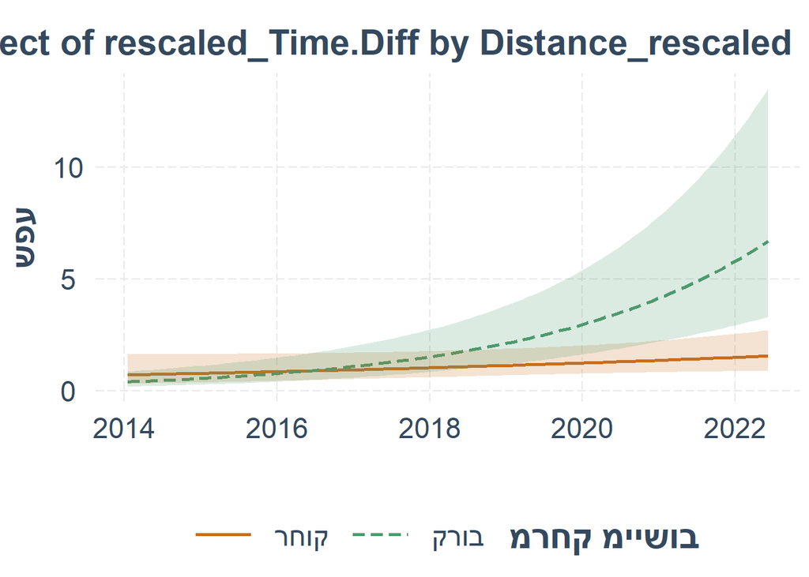

```r
Canis_inetract <- interact_plot(model = glm.Canis.aureus, data=env_data, pred = rescaled_Time.Diff, modx = Distance_rescaled, modx.values = "plus-minus", partial.residuals = F, jitter = c(0.2), point.size = 3, rug = F, point.shape = F, interval = T, colors = "Dark2") + scale_x_continuous(breaks=c(-1.233466888,-0.601840099,0.028922631,0.66054942,1.291312151), labels=c("June 2014", "June 2016", "June 2018", "June 2020", "June 2022"), name = "Time")


# Canis.interaction.near <- data.frame(Site = "Bislach",
#                            rescaled_Time.Diff = c(-1.180759317,1.344019721),
#                            Distance_rescaled = -0.6386647)
#
# predict(glm.Canis.aureus, newdata = Canis.interaction.near,
#         type = "response")
#
# #Increase of 1352.67% over time near settlements
#
# (6.1172275 /0.4211005 ) - 1
#
# #or 14.52 fold
# (6.1172275/0.4211005)
#
#
# Canis.interaction.far <- data.frame(Site = "Bislach",
#                            rescaled_Time.Diff = c(-1.180759317,1.344019721),
#                            Distance_rescaled = 0.6095490)
#
# predict(glm.Canis.aureus, newdata = Canis.interaction.far,
#         type = "response")
#
# #Decrease of 109.74% over time far from settlements
#
# (1.5234634 /0.7263442 ) - 1
#
# #or 2.09 fold
# (1.5234634/0.7263442)

canis_aur_interact_plot <- plot_model_interaction(P.anal = env_data,
                                                  m = glm.Canis.aureus,
                                                  eff2plot = "rescaled_Time.Diff",
                                                  modvar2plot = "Distance_rescaled",
                                                  plot_points=FALSE,
                                                  plot_residuals=FALSE,
                                                  export_plot=TRUE,
                                                  ylabel = NULL,
                                                  fontname = "Almoni ML v5 AAA",
                                                  fontsize=22,
                                                  pdf_width=160,
                                                  outpath = "../output/negev_highlands/",
                                                  legend_position = "bottom")
```

```r
#Testing whether trends and means are different from zero

#Calculate mean and sd of distance
sd_distance <- sd(env_data$Distance_rescaled)
print(sd_distance)
```

```
## [1] 0.6241069
```

```r
mean_distance <- mean(env_data$Distance_rescaled)
print(mean_distance)
```

```
## [1] -0.01455781
```

```r
#calculate +/1 1 SD
small_distance <- mean_distance - sd_distance
large_distance <- mean_distance + sd_distance

#Test whether temporal trend is different from zero
mm_rescaled_time <- emtrends(glm.Canis.aureus, specs = "Distance_rescaled", var = "rescaled_Time.Diff", type = "response", at = list(Distance_rescaled = c(small_distance,large_distance)))
print(mm_rescaled_time)
```

```
##  Distance_rescaled rescaled_Time.Diff.trend    SE  df asymp.LCL asymp.UCL
##             -0.639                    1.060 0.169 Inf    0.7280     1.392
##              0.610                    0.293 0.177 Inf   -0.0544     0.641
##
## Results are averaged over the levels of: Site
## Confidence level used: 0.95
```

```r
test_results_mm_rescaled_time <- test(mm_rescaled_time, null = 0, adjust = "fdr")
print(test_results_mm_rescaled_time)
```

```
##  Distance_rescaled rescaled_Time.Diff.trend    SE  df z.ratio p.value
##             -0.639                    1.060 0.169 Inf   6.259  <.0001
##              0.610                    0.293 0.177 Inf   1.653  0.0983
##
## Results are averaged over the levels of: Site
## P value adjustment: fdr method for 2 tests
```

```r
#Testing whether abundance is higher near or far from settlements
pairwise_distance <- emmeans(object = glm.Canis.aureus, ~Distance_rescaled*rescaled_Time.Diff, at = list(Distance_rescaled = c(small_distance,large_distance)))
test_results_distance <- test(pairs(pairwise_distance, by="rescaled_Time.Diff"), by=NULL, adjust="fdr")
print(test_results_distance)
```

```
##  contrast
##  (Distance_rescaled-0.638664675609571) - Distance_rescaled0.609549046300846
##  rescaled_Time.Diff estimate    SE  df z.ratio p.value
##               0.417    0.679 0.205 Inf   3.309  0.0009
##
## Results are averaged over the levels of: Site
## Results are given on the log (not the response) scale.
```

temporal trend is significantly different from zero in small distances from settlements (p < 0.0001) and not significantly different from zero in large distances (p = 0.098)

On average over time, Jackal abundance is significantly higher near settlements (p = 0.0009)

```r
####Gazella dorcas####

Gazella.dorcas <- spp_no_rare[,"Gazella.dorcas"]
glm.Gazella.dorcas <- glm.nb(formula = Gazella.dorcas ~ Distance_rescaled + rescaled_Time.Diff + Site, data = env_data)
print(summary(glm.Gazella.dorcas))
```

```
##
## Call:
## glm.nb(formula = Gazella.dorcas ~ Distance_rescaled + rescaled_Time.Diff +
##     Site, data = env_data, init.theta = 0.2088578803, link = log)
##
## Coefficients:
##                      Estimate Std. Error z value Pr(>|z|)
## (Intercept)        -1.264e+00  4.337e-01  -2.915 0.003559 **
## Distance_rescaled   1.164e+00  3.724e-01   3.126 0.001772 **
## rescaled_Time.Diff  7.440e-01  2.231e-01   3.335 0.000853 ***
## SiteEzuz            1.179e+00  5.201e-01   2.267 0.023396 *
## SiteMerhav Am       7.277e-02  5.845e-01   0.125 0.900915
## SiteSde Boker       3.752e-01  5.184e-01   0.724 0.469245
## SiteYeruham        -3.606e+01  7.395e+06   0.000 0.999996
## ---
## Signif. codes:  0 '***' 0.001 '**' 0.01 '*' 0.05 '.' 0.1 ' ' 1
##
## (Dispersion parameter for Negative Binomial(0.2089) family taken to be 1)
##
##     Null deviance: 199.38  on 297  degrees of freedom
## Residual deviance: 130.99  on 291  degrees of freedom
## AIC: 480.61
##
## Number of Fisher Scoring iterations: 1
##
##
##               Theta:  0.2089
##           Std. Err.:  0.0423
##
##  2 x log-likelihood:  -464.6090
```

```r
coef(glm.Gazella.dorcas)
```

```
##        (Intercept)  Distance_rescaled rescaled_Time.Diff           SiteEzuz
##        -1.26403563         1.16427008         0.74402049         1.17903270
##      SiteMerhav Am      SiteSde Boker        SiteYeruham
##         0.07276738         0.37518689       -36.05655008
```

```r
coef(mva_m2)
```

```
##                                      Canis.aureus Gazella.dorcas Hyaena.hyaena
## (Intercept)                           0.202471624     -1.0331143  -0.673103688
## Distance_rescaled                    -0.288347160      1.5811782  -0.063669196
## rescaled_Time.Diff                    0.667674257      0.8084377   0.447480193
## SiteEzuz                              0.694390321      0.9537089  -1.931047366
## SiteMerhav Am                         0.671816264     -0.4328389  -0.660501490
## SiteSde Boker                        -0.002144141     -0.1411651  -0.830281862
## SiteYeruham                           0.418133246    -13.9665941  -0.004746017
## Distance_rescaled:rescaled_Time.Diff -0.614116326     -0.9795058   0.285629373
##                                      Hystrix.indica Lepus.capensis
## (Intercept)                             -0.26649537    -1.08313007
## Distance_rescaled                       -0.77978978     1.07360882
## rescaled_Time.Diff                       0.44329402     0.04304816
## SiteEzuz                                -0.16920989     1.37732752
## SiteMerhav Am                            0.30876418    -0.36155749
## SiteSde Boker                           -0.03221625    -0.57325986
## SiteYeruham                              1.35263904    -0.22208773
## Distance_rescaled:rescaled_Time.Diff    -0.13312087     0.68802607
##                                      Vulpes.vulpes
## (Intercept)                             -0.8808563
## Distance_rescaled                       -0.3101542
## rescaled_Time.Diff                       0.3323375
## SiteEzuz                                -0.2880808
## SiteMerhav Am                            1.6010889
## SiteSde Boker                            1.5908155
## SiteYeruham                              1.2124690
## Distance_rescaled:rescaled_Time.Diff     0.1554621
```

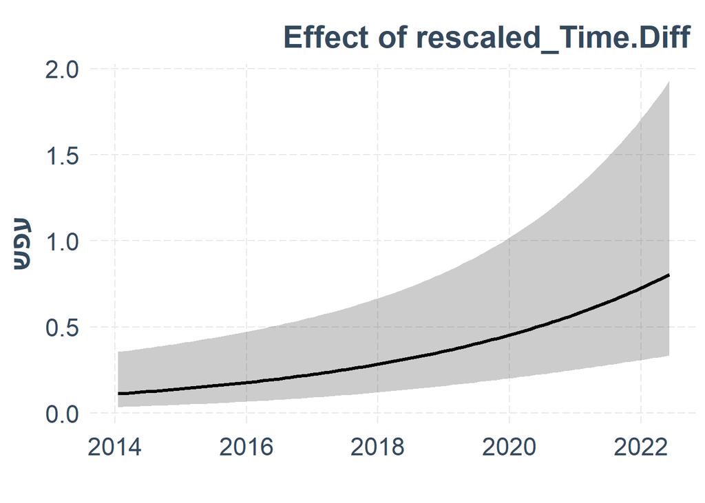

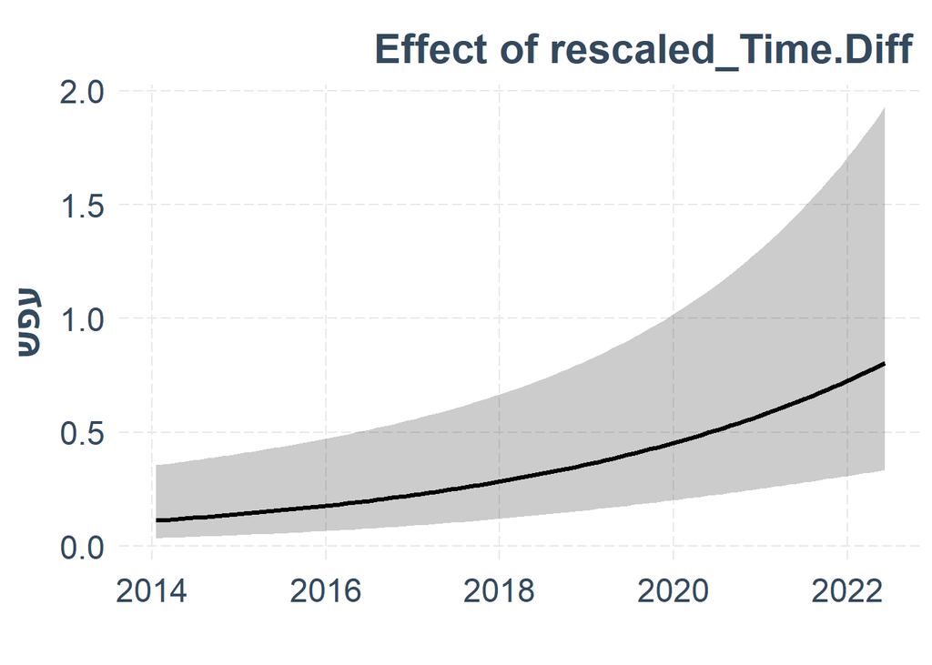

```r
# Time graph - need to change y axis scale in plot_model_effect_mammals (uncomment lines 128 - 129 in function)

source("../functions/plot_model_effect_mammals.R")

plot_model_effect(P.anal = env_data, m = glm.Gazella.dorcas, eff2plot = "rescaled_Time.Diff", plot_points=FALSE, plot_residuals=FALSE, export_plot=TRUE, ylabel = NULL, fontname = "Almoni ML v5 AAA", fontsize=22, pdf_width=160, outpath = "../output/negev_highlands/")
```

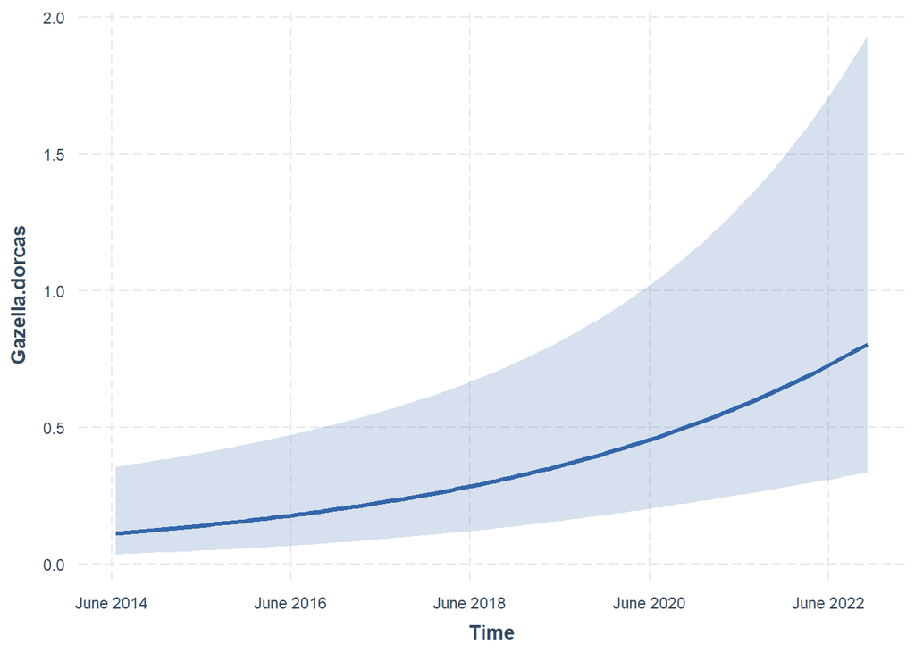

```r
dorcas_time <- effect_plot(model = glm.Gazella.dorcas, data=env_data, pred = rescaled_Time.Diff, interval = T, plot.points = F, jitter = c(0.1,0), point.size = 3, cat.pred.point.size = 4, partial.residuals = F, colors = "Qual1") + scale_x_continuous(breaks=c(-1.233466888,-0.601840099,0.028922631,0.66054942,1.291312151), labels=c("June 2014", "June 2016", "June 2018", "June 2020", "June 2022"), name = "Time")

dorcas_time
```

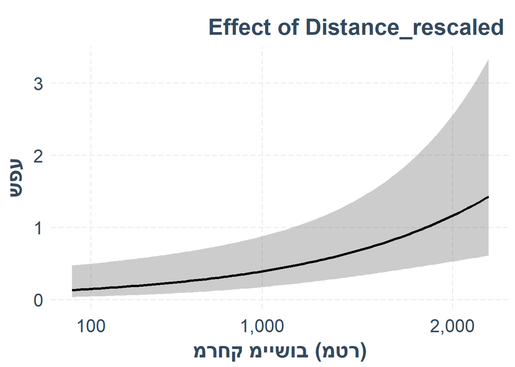

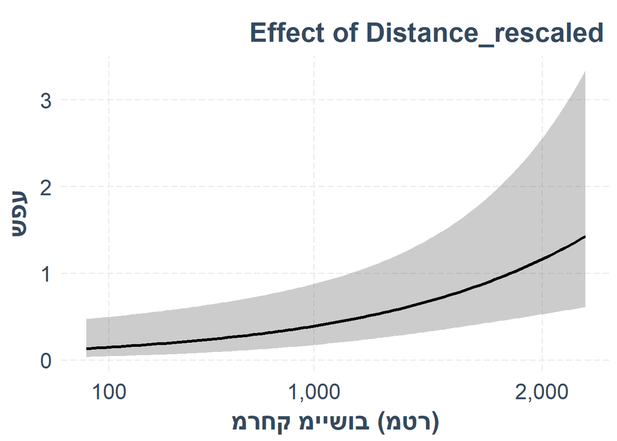

```r
# #Time references - 01/08/2014 and 01/08/2022
# dorcase.time <- data.frame(Site = "Bislach",
#                            rescaled_Time.Diff = c(-1.180759317,1.344019721),
#                            Distance_rescaled = -0.01455781)
#
# predict(glm.Gazella.dorcas, newdata = dorcase.time,
#         type = "response")
#
# #Increase of 554.35% during monitoring year or 6.54 fold
# (0.7550233 /0.1153835 ) - 1
# (0.7550233/0.1153835)
#
# sum(P.anal$`Gazella dorcas`[P.anal$year=="2014"])
# sum(P.anal$`Gazella dorcas`[P.anal$year=="2022"])
#
# #Increase of 1500% during monitoring years or 16 fold
#
# (96/6 - 1) *100
# 96/6


plot_model_effect(P.anal = env_data, m = glm.Gazella.dorcas, eff2plot = "Distance_rescaled", plot_points=FALSE, plot_residuals=FALSE, export_plot=TRUE, ylabel = NULL, fontname = "Almoni ML v5 AAA", fontsize=22, pdf_width=160, outpath = "../output/negev_highlands/")
```